# Sentiment_Analysis

**Reddit Integration**

```python
import praw

user_agent = "Scraper 1.0 by /u/Grand-Ad7174"
reddit = praw.Reddit(
    client_id = "-7K2XoueOH4wvgYzEGgSRw",
    client_secret = "R5FaeZgtDVIHXSqKegSqKqZBQAZVsg",
    user_agent = user_agent
)
```

**Fetching Different Sentence related to various topic**

```python
subreddits = ['politics', 'OpenAI', 'india', 'funny', 'AskReddit', 'MachineLearning', 'Conestoga', 'news', 'canada', 'International', 'google', 'memes']
headlines = set()

for subreddit_name in subreddits:
    for submission in reddit.subreddit(subreddit_name).top(limit=None):
        headlines.add(submission.title)

print(len(headlines))
```

```
11854
```

**Getting them in Data Frame**

```python
import pandas as pd

df = pd.DataFrame(headlines)
df.head()
```

|  | 0 |
| --- | --- |
| 0 | Kazakhstan and the Price of Russia's Empire |
| 1 | For opening Home instead of Drive gang |
| 2 | 'A welcome they'll remember': Ukrainian mother... |
| 3 | Trump castigates Biden and assures that he cou... |
| 4 | WE, The people of India: |

```python
df.shape
```

```
(11854, 1)
```

**Annotate the dataset using `SentimentIntensityAnalyzer`**

```python
from nltk.sentiment.vader import SentimentIntensityAnalyzer as SIA
from pprint import pprint

sia = SIA()
results = []

for line in headlines:
    pol_score = sia.polarity_scores(line)
    pol_score['headlines'] = line
    results.append(pol_score)

pprint(results[:3], width=100)
```

```
[{'compound': 0.0,
  'headlines': "Kazakhstan and the Price of Russia's Empire",
  'neg': 0.0,
  'neu': 1.0,
  'pos': 0.0},
 {'compound': 0.0,
  'headlines': 'For opening Home instead of Drive gang',
  'neg': 0.0,
  'neu': 1.0,
  'pos': 0.0},
 {'compound': 0.4404,
  'headlines': "'A welcome they'll remember': Ukrainian mother is ready to fight if Russia invades",
  'neg': 0.144,
  'neu': 0.552,
  'pos': 0.304}]
```

```python
df = pd.DataFrame.from_records(results)
df.head()
```

|  | neg | neu | pos | compound | headlines |
| --- | --- | --- | --- | --- | --- |
| 0 | 0.000 | 1.000 | 0.000 | 0.0000 | Kazakhstan and the Price of Russia's Empire |
| 1 | 0.000 | 1.000 | 0.000 | 0.0000 | For opening Home instead of Drive gang |
| 2 | 0.144 | 0.552 | 0.304 | 0.4404 | 'A welcome they'll remember': Ukrainian mother... |
| 3 | 0.159 | 0.706 | 0.135 | -0.1027 | Trump castigates Biden and assures that he cou... |
| 4 | 0.000 | 1.000 | 0.000 | 0.0000 | WE, The people of India: |

```python
df['label'] = 0
df.loc[df['compound'] > 0.05, 'label'] = 1
df.loc[df['compound'] < -0.05, 'label'] = -1
display(df.head())
```

|  | neg | neu | pos | compound | headlines | label |
| --- | --- | --- | --- | --- | --- | --- |
| 0 | 0.000 | 1.000 | 0.000 | 0.0000 | Kazakhstan and the Price of Russia's Empire | 0 |
| 1 | 0.000 | 1.000 | 0.000 | 0.0000 | For opening Home instead of Drive gang | 0 |
| 2 | 0.144 | 0.552 | 0.304 | 0.4404 | 'A welcome they'll remember': Ukrainian mother... | 1 |
| 3 | 0.159 | 0.706 | 0.135 | -0.1027 | Trump castigates Biden and assures that he cou... | -1 |
| 4 | 0.000 | 1.000 | 0.000 | 0.0000 | WE, The people of India: | 0 |

```python
df2 = df[['headlines', 'label']]
df2.head()
```

|  | headlines | label |
| --- | --- | --- |
| 0 | Kazakhstan and the Price of Russia's Empire | 0 |
| 1 | For opening Home instead of Drive gang | 0 |
| 2 | 'A welcome they'll remember': Ukrainian mother... | 1 |
| 3 | Trump castigates Biden and assures that he cou... | -1 |
| 4 | WE, The people of India: | 0 |

**Saving the Processed DataFrame in CSV file**

```python
df2.to_csv('Sentimental_Analysis.csv', encoding='utf-8', index=False)
df.label.value_counts()
```

```
label
 0    5118
 1    3491
-1    3245
Name: count, dtype: int64
```

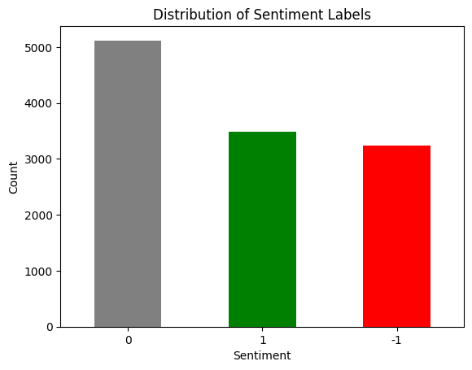

```python
import matplotlib.pyplot as plt

# Get the counts of each label
label_counts = df2['label'].value_counts()

# Plotting
label_counts.plot(kind='bar', color=['grey', 'green', 'red'])
plt.title('Distribution of Sentiment Labels')
plt.xlabel('Sentiment')
plt.ylabel('Count')
plt.xticks(rotation=0)  # Optional: Rotate x labels if needed
plt.show()  # Display the plot interactively
```

### **1. Load the Data**

```python
import pandas as pd

data = pd.read_csv('Sentimental_Analysis.csv')
data.head()
```

|  | headlines | label |
| --- | --- | --- |
| 0 | Kazakhstan and the Price of Russia's Empire | 0 |
| 1 | For opening Home instead of Drive gang | 0 |
| 2 | 'A welcome they'll remember': Ukrainian mother... | 1 |
| 3 | Trump castigates Biden and assures that he cou... | -1 |
| 4 | WE, The people of India: | 0 |

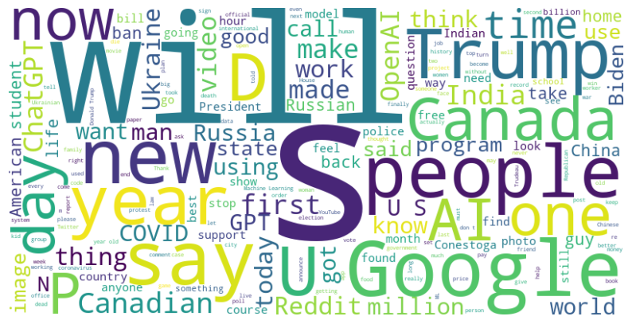

```python
from wordcloud import WordCloud
import matplotlib.pyplot as plt

# Assuming your text data is stored in a column named 'text', replace 'text' with the actual column name
text_data = ' '.join(data['headlines'])

# Generate word cloud
wordcloud = WordCloud(width=800, height=400, background_color='white').generate(text_data)

# Display word cloud
plt.figure(figsize=(10, 6))
plt.imshow(wordcloud, interpolation='bilinear')
plt.axis('off')
plt.show()
```

- This is a visualization where the size of each word in the word cloud corresponds to its frequency in the 'headlines' column of the DataFrame.
- It provides a quick and intuitive way to visualize the most common words in the text data.

### **2. Preprocessing the Data**

```python
import nltk
from nltk.corpus import stopwords, wordnet
from nltk.tokenize import word_tokenize
from nltk.stem import WordNetLemmatizer
import string
import re
import emoji

def preprocess_text(text):
    def replace_slang(text):
        words = text.split()
        replaced_words = []
        for word in words:
            synsets = wordnet.synsets(word)
            if synsets:
                replaced_words.append(synsets[0].lemmas()[0].name())
            else:
                replaced_words.append(word)
        return ' '.join(replaced_words)

    # Handle hashtags
    text = re.sub(r'#\w+', '', text)

    # Handle emojis
    text = emoji.demojize(text)

    # Replace slang words
    text = replace_slang(text)

    # Tokenization
    tokens = word_tokenize(text)

    # Lowercasing
    tokens = [token.lower() for token in tokens]

    # Stop-word removal
    stop_words = set(stopwords.words('english'))
    filtered_tokens = [word for word in tokens if word.lower() not in stop_words]

    # Remove punctuation
    punctuation_list = list(string.punctuation)
    filtered_tokens = [word for word in filtered_tokens if word not in punctuation_list]

    # POS tagging
    pos_tags = nltk.pos_tag(filtered_tokens)

    # Lemmatization
    lemmatizer = WordNetLemmatizer()
    lemmatized_tokens = []

    for word, pos in pos_tags:

        if pos.startswith('N'):  # N for Noun
            lemmatized_tokens.append(lemmatizer.lemmatize(word, pos='n'))

        elif pos.startswith('V'):  # V for Verb
            lemmatized_tokens.append(lemmatizer.lemmatize(word, pos='v'))

        elif pos.startswith('J'):   # J for Adjective
            lemmatized_tokens.append(lemmatizer.lemmatize(word, pos='a'))

        elif pos.startswith('R'):   # R for Adverb
            lemmatized_tokens.append(lemmatizer.lemmatize(word, pos='r'))

        else:
            lemmatized_tokens.append(word)

    lemmatized_text = ' '.join(lemmatized_tokens)

    return lemmatized_text, pos_tags

# Apply preprocessing function to the 'headlines' column
data['lemmatized_tokens'], data['pos_tags'] = zip(*data['headlines'].apply(preprocess_text))

display(data.head())
```

|  | headlines | label | lemmatized_tokens | pos_tags |
| --- | --- | --- | --- | --- |
| 0 | Kazakhstan and the Price of Russia's Empire | 0 | kazakhstan monetary_value russia 's empire | [(kazakhstan, VB), (monetary_value, NN), (russ... |
| 1 | For opening Home instead of Drive gang | 0 | open home alternatively drive gang | [(opening, VBG), (home, NN), (alternatively, R... |
| 2 | 'A welcome they'll remember': Ukrainian mother... | 1 | welcome 'll remember ukrainian mother ready ba... | [(welcome, JJ), ('ll, MD), (remember, VB), (uk... |
| 3 | Trump castigates Biden and assures that he cou... | -1 | trump chastise biden guarantee helium could “ ... | [(trump, NN), (chastise, NN), (biden, JJ), (gu... |
| 4 | WE, The people of India: | 0 | people india | [(people, NNS), (india, VBP)] |

- The above code defines a function called preprocess_text that preprocesses text data by performing various steps such as handling hashtags, emojis, slang words, tokenization, lowercasing, stop-word removal, punctuation removal, POS tagging, and lemmatization.
- Then, the function is applied to the 'headlines' column of a DataFrame called data. The preprocessed text data, as well as the POS tags, are stored in new columns named 'lemmatized_tokens' and 'pos_tags', respectively.
- Finally, the first few rows of the DataFrame data are displayed to show the results of preprocessing.

```python
print(data.shape)
```

```
(11854, 4)
```

### **3. Feature Extraction**

```python
import os
os.environ['HF_HUB_DISABLE_SYMLINKS_WARNING'] = '1'
```

- This code sets an environment variable called 'HF_HUB_DISABLE_SYMLINKS_WARNING' to '1'.
- The variable name suggests that it's related to the Hugging Face Hub, which is a repository of pre-trained models and datasets for natural language processing tasks.
- The value '1' likely disables a specific warning related to symlinks (symbolic links) in the Hugging Face Hub. Symbolic links are a type of file that contains a reference to another file or directory in the form of an absolute or relative path.

**TF-IDF vectorizer**

```python
from sklearn.feature_extraction.text import TfidfVectorizer
from gensim.models import Word2Vec
from transformers import BertTokenizer, BertModel
import numpy as np

# TF-IDF
tfidf_vectorizer = TfidfVectorizer()
tfidf_features = tfidf_vectorizer.fit_transform(data['lemmatized_tokens'])
tfidf_features
```

```
<11854x13160 sparse matrix of type '<class 'numpy.float64'>'
	with 106876 stored elements in Compressed Sparse Row format>
```

- The TF-IDF matrix contains numerical representations of the text data in a format suitable for machine learning algorithms.
- Each row in the TF-IDF matrix corresponds to a document or sample, while each column represents a unique term (word) in the entire corpus.
- The shape of the TF-IDF matrix provides insights into the dimensionality of the feature space used for modeling.
- With 11,854 samples and 13,160 features, the TF-IDF matrix represents a high-dimensional space where each document is represented by a vector of TF-IDF scores for each unique term in the corpus.

**Word2Vec**

```python
# Word2Vec
word2vec_model = Word2Vec(data['lemmatized_tokens'], vector_size=1000, window=5, min_count=1, workers=4)
word2vec_features = np.array([np.mean([word2vec_model.wv[word] for word in tokens if word in word2vec_model.wv] or [np.zeros(1000)], axis=0) for tokens in data['lemmatized_tokens']])
word2vec_features
```

```
array([[ 0.11848618, -0.03578262,  0.03662472, ..., -0.03009141,
        -0.08213325,  0.06133516],
       [ 0.13034287, -0.04962555,  0.03311484, ..., -0.03122623,
        -0.06648224,  0.05550264],
       [ 0.1166703 , -0.04594474,  0.01737331, ..., -0.02461837,
        -0.02780494,  0.04960829],
       ...,
       [ 0.09744098, -0.04821818,  0.00431841, ..., -0.03104656,
        -0.02872113,  0.05855545],
       [ 0.12572995, -0.0556548 ,  0.01433889, ..., -0.03007691,
        -0.0283853 ,  0.04905506],
       [ 0.11516143, -0.04121148,  0.0190764 , ..., -0.02359966,
        -0.0596039 ,  0.03877932]])
```

**BERT**

```python
# BERT
tokenizer = BertTokenizer.from_pretrained('bert-base-uncased')
model = BertModel.from_pretrained('bert-base-uncased')
bert_features = []

for text in data['lemmatized_tokens']:
    inputs = tokenizer(text, return_tensors='pt', padding=True, truncation=True)
    outputs = model(**inputs)
    pooled_output = outputs.pooler_output
    bert_features.append(pooled_output.detach().numpy())

bert_features = np.vstack(bert_features)
bert_features
```

```
array([[-0.9007588 , -0.6751699 , -0.9555547 , ..., -0.89348066,
        -0.75101846,  0.8032955 ],
       [-0.8416413 , -0.3290357 , -0.48723167, ..., -0.19734132,
        -0.69504863,  0.8792799 ],
       [-0.843136  , -0.43676448, -0.79449594, ..., -0.6893963 ,
        -0.62440175,  0.86979014],
       ...,
       [-0.85744953, -0.37091577, -0.41964144, ..., -0.05788232,
        -0.621631  ,  0.7956827 ],
       [-0.8767305 , -0.47611266, -0.8841584 , ..., -0.73411137,
        -0.76063865,  0.81993806],
       [-0.8756796 , -0.49258462, -0.81348634, ..., -0.6496388 ,
        -0.55484694,  0.85053134]], dtype=float32)
```

- BERT features represent each document in a 768-dimensional vector space, capturing the contextual information of the text.
- BERT is a powerful language model that is pre-trained on large corpora and can capture intricate relationships between words and their contexts.
- The BERT feature matrix provides dense representations of documents suitable for various downstream NLP tasks such as classification, clustering, or regression.
- The 768-dimensional BERT feature vectors represent a compact yet rich representation of the text data, enabling effective modeling of semantic relationships.

```python
print("TF-IDF Features shape:", tfidf_features.shape)
print("Word2Vec Features shape:", word2vec_features.shape)
print("BERT Features shape:", bert_features.shape)
```

```
TF-IDF Features shape: (11854, 13160)
Word2Vec Features shape: (11854, 1000)
BERT Features shape: (11854, 768)
```

### **4. Model Selection and Training**

```python
from sklearn.model_selection import train_test_split
from sklearn.svm import SVC
from sklearn.metrics import accuracy_score
```

**Splitting the Dataset**

```python
# Splitting the dataset
X_tfidf = tfidf_features
X_word2vec = word2vec_features
X_bert = bert_features
y = data['label']
X_tfidf_train, X_tfidf_test, y_train, y_test = train_test_split(X_tfidf, y, test_size=0.2, random_state=42)
X_word2vec_train, X_word2vec_test, _, _ = train_test_split(X_word2vec, y, test_size=0.2, random_state=42)
X_bert_train, X_bert_test, _, _ = train_test_split(X_bert, y, test_size=0.2, random_state=42)
```

- The code efficiently splits the dataset into training and testing sets for each type of feature representation: TF-IDF, Word2Vec, and BERT.
- By splitting the dataset, it enables the evaluation of machine learning models on each type of feature independently.
- Using a consistent random_state value (42 in this case) ensures reproducibility of the results across different runs.
- The choice of the test size (20% in this case) balances the trade-off between having sufficient data for training and having enough data for testing the model's performance.

**SVM model for TF-IDF features**

```python
# Training and evaluating SVM model for TF-IDF features
svm_tfidf = SVC(kernel='linear', random_state=42)
svm_tfidf.fit(X_tfidf_train, y_train)

# Make prediction
y_train_pred_tfidf = svm_tfidf.predict(X_tfidf_train)
y_test_pred_tfidf = svm_tfidf.predict(X_tfidf_test)

# Checking Accuracy
accuracy_train_tfidf = accuracy_score(y_train, y_train_pred_tfidf)
accuracy_test_tfidf = accuracy_score(y_test, y_test_pred_tfidf)

print("TF-IDF Accuracy (Training):", accuracy_train_tfidf)
print("TF-IDF Accuracy (Testing):", accuracy_test_tfidf)
```

```
TF-IDF Accuracy (Training): 0.9132131182115364
TF-IDF Accuracy (Testing): 0.7629692113032476
```

**Evaluation on SVM model for TF-IDF feature**

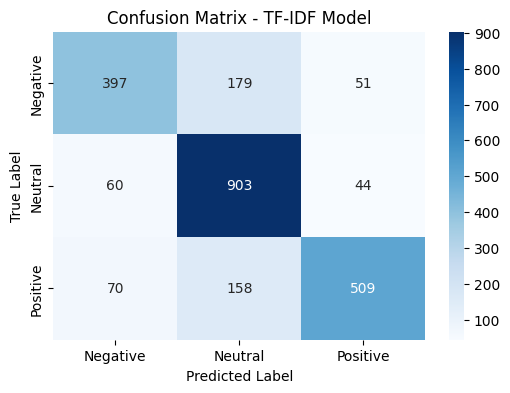

```python
from sklearn.metrics import confusion_matrix
import seaborn as sns

# Calculate confusion matrix
conf_matrix_tfidf = confusion_matrix(y_test, y_test_pred_tfidf)

# Plot confusion matrix
plt.figure(figsize=(6, 4))
sns.heatmap(conf_matrix_tfidf, annot=True, fmt='d', cmap='Blues',
            xticklabels=['Negative', 'Neutral', 'Positive'],
            yticklabels=['Negative', 'Neutral', 'Positive'])
plt.title('Confusion Matrix - TF-IDF Model')
plt.xlabel('Predicted Label')
plt.ylabel('True Label')
plt.show()
```

The confusion matrix represents the performance of a model. Let’s analyze the insights from this confusion matrix:

1. True Positives (TP):

The diagonal elements represent the number of correct predictions for each class. the diagonal elements are:

- They are Negative and model predict them also as Negative: 397
- They are Neutral and model predict them also as Neutral: 903
- They are Positive and model predict them also as Positive: 509
2. False Positives (FP):

The values outside the diagonal in each row represent the misclassifications.

- The model predicted 179 negative samples as neutral.
- The model predicted 158 positive samples as neutral.
- These misclassifications can provide insights into areas where the model needs improvement.
3. False Negatives (FN):

The values outside the diagonal in each column represent instances where the model failed to predict a certain class.

```python
import pandas as pd
from sklearn.metrics import classification_report

# Classification report for TF-IDF model
report_tfidf = classification_report(y_test, y_test_pred_tfidf, output_dict=True, zero_division=1)
df_tfidf = pd.DataFrame(report_tfidf).transpose()
df_tfidf.index.name = 'TF-IDF Model'

# Display DataFrames
print("TF-IDF Model Report:")
display(df_tfidf)
```

```
TF-IDF Model Report:
```

| TF-IDF Model | precision | recall | f1-score | support |
| --- | --- | --- | --- | --- |
| -1 | 0.753321 | 0.633174 | 0.688042 | 627.000000 |
| 0 | 0.728226 | 0.896723 | 0.803738 | 1007.000000 |
| 1 | 0.842715 | 0.690638 | 0.759135 | 737.000000 |
| accuracy | 0.762969 | 0.762969 | 0.762969 | 0.762969 |
| macro avg | 0.774754 | 0.740178 | 0.750305 | 2371.000000 |
| weighted avg | 0.770450 | 0.762969 | 0.759278 | 2371.000000 |

- **Precision:** Precision is the ratio of correctly predicted positive observations to the total predicted positives. It measures the accuracy of positive predictions. A higher precision indicates fewer false positives.
- **Recall:** Recall is the ratio of correctly predicted positive observations to all actual positives. It measures the ability of the model to find all relevant cases within the data. A higher recall indicates fewer false negatives.
- **F1-score:** The F1-score is the harmonic mean of precision and recall. It provides a balance between precision and recall. It is a useful metric when the class distribution is imbalanced.
1. Class -1:

Precision: 0.753 (75.3%) - 75.3% of the instances predicted as class -1 were actually class -1.  
Recall: 0.633 (63.3%) - The model correctly identified 63.3% of all actual class -1 instances.  
F1-score: 0.688 (68.8%) - The harmonic mean of precision and recall for class -1.

2. Class 0:

Precision: 0.728 (72.8%)  
Recall: 0.897 (89.7%)  
F1-score: 0.804 (80.4%)

3. Class 1:

Precision: 0.843 (84.3%)  
Recall: 0.691 (69.1%)  
F1-score: 0.759 (75.9%)

**SVM model for Word2Vec features**

```python
# Training and evaluating SVM model for Word2Vec features
svm_word2vec = SVC(kernel='linear', random_state=42)
svm_word2vec.fit(X_word2vec_train, y_train)

# Make prediction
y_train_pred_word2vec = svm_word2vec.predict(X_word2vec_train)
y_test_pred_word2vec = svm_word2vec.predict(X_word2vec_test)

# Checking Accuracy
accuracy_train_word2vec = accuracy_score(y_train, y_train_pred_word2vec)
accuracy_test_word2vec = accuracy_score(y_test, y_test_pred_word2vec)

print("Word2Vec Accuracy (Training):", accuracy_train_word2vec)
print("Word2Vec Accuracy (Testing):", accuracy_test_word2vec)
```

```
Word2Vec Accuracy (Training): 0.43351260149741644
Word2Vec Accuracy (Testing): 0.4247153099957824
```

- The SVM model trained on Word2Vec features achieves a relatively low accuracy of approximately 43.35% on the training data and 42.47% on the testing data.
- The significantly lower accuracy compared to the TF-IDF model suggests that the Word2Vec features may not capture the relevant patterns or semantics as effectively for this classification task.
- It's possible that the Word2Vec model trained on the provided lemmatized tokens did not adequately capture the semantics or context of the text data, leading to poor performance in the SVM classifier.

**Evaluation on SVM model for Word2Vec feature**

```
Confusion Matrix - Word2Vec Model:
[[   0  627    0]
 [   0 1007    0]
 [   0  737    0]]
```

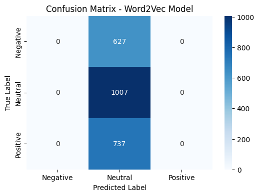

```python
# Calculate confusion matrix for Word2Vec model
conf_matrix_word2vec = confusion_matrix(y_test, y_test_pred_word2vec)

print("Confusion Matrix - Word2Vec Model:")
print(conf_matrix_word2vec)


# Plot confusion matrix for Word2Vec model
plt.figure(figsize=(6, 4))
sns.heatmap(conf_matrix_word2vec, annot=True, fmt='d', cmap='Blues',
            xticklabels=['Negative', 'Neutral', 'Positive'],
            yticklabels=['Negative', 'Neutral', 'Positive'])
plt.title('Confusion Matrix - Word2Vec Model')
plt.xlabel('Predicted Label')
plt.ylabel('True Label')
plt.show()
```

1. True Positives (TP):

The diagonal elements represent the number of correct predictions for each class. In this case, the model correctly predicted: 1007 samples as neutral (True Positives).

2. False Positives (FP):

The values outside the diagonal in each row represent the misclassifications. For example: The model predicted 627 negative samples as neutral (False Positives). The model predicted 737 positive samples as neutral (False Positives).

```python
# Classification report for Word2Vec model
report_word2vec = classification_report(y_test, y_test_pred_word2vec, output_dict=True, zero_division=1)
df_word2vec = pd.DataFrame(report_word2vec).transpose()
df_word2vec.index.name = 'Word2Vec Model'

print("Word2Vec Model Report:")
display(df_word2vec)
```

```
Word2Vec Model Report:
```

| Word2Vec Model | precision | recall | f1-score | support |
| --- | --- | --- | --- | --- |
| -1 | 1.000000 | 0.000000 | 0.000000 | 627.000000 |
| 0 | 0.424715 | 1.000000 | 0.596211 | 1007.000000 |
| 1 | 1.000000 | 0.000000 | 0.000000 | 737.000000 |
| accuracy | 0.424715 | 0.424715 | 0.424715 | 0.424715 |
| macro avg | 0.808238 | 0.333333 | 0.198737 | 2371.000000 |
| weighted avg | 0.755668 | 0.424715 | 0.253220 | 2371.000000 |

**SVM model for BERT features**

```python
# Training and evaluating SVM model for BERT features
svm_bert = SVC(kernel='linear', random_state=42)
svm_bert.fit(X_bert_train, y_train)

# Make prediction
y_train_pred_bert = svm_bert.predict(X_bert_train)
y_test_pred_bert = svm_bert.predict(X_bert_test)

# Checking Accuracy
accuracy_train_bert = accuracy_score(y_train, y_train_pred_bert)
accuracy_test_bert = accuracy_score(y_test, y_test_pred_bert)

print("BERT Accuracy (Training):", accuracy_train_bert)
print("BERT Accuracy (Testing):", accuracy_test_bert)
```

```
BERT Accuracy (Training): 0.668881155752399
BERT Accuracy (Testing): 0.6339097427245888
```

**Evaluation on SVM model for BERT feature**

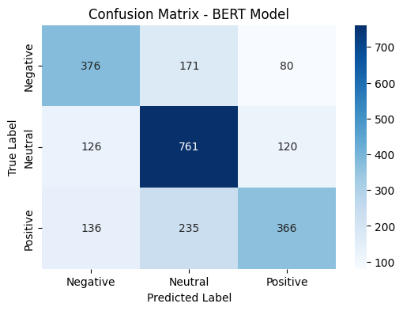

```python
# Calculate confusion matrix for BERT model
conf_matrix_bert = confusion_matrix(y_test, y_test_pred_bert)

# Plot confusion matrix for BERT model
plt.figure(figsize=(6, 4))
sns.heatmap(conf_matrix_bert, annot=True, fmt='d', cmap='Blues',
            xticklabels=['Negative', 'Neutral', 'Positive'],
            yticklabels=['Negative', 'Neutral', 'Positive'])
plt.title('Confusion Matrix - BERT Model')
plt.xlabel('Predicted Label')
plt.ylabel('True Label')
plt.show()
```

```python
# Classification report for BERT model
report_bert = classification_report(y_test, y_test_pred_bert, output_dict=True, zero_division=1)
df_bert = pd.DataFrame(report_bert).transpose()
df_bert.index.name = 'BERT Model'

# Display DataFrames
print("\nBERT Model Report:")
display(df_bert)
```

```
BERT Model Report:
```

| BERT Model | precision | recall | f1-score | support |
| --- | --- | --- | --- | --- |
| -1 | 0.589342 | 0.599681 | 0.594466 | 627.00000 |
| 0 | 0.652099 | 0.755710 | 0.700092 | 1007.00000 |
| 1 | 0.646643 | 0.496608 | 0.561781 | 737.00000 |
| accuracy | 0.633910 | 0.633910 | 0.633910 | 0.63391 |
| macro avg | 0.629361 | 0.617333 | 0.618780 | 2371.00000 |
| weighted avg | 0.633807 | 0.633910 | 0.629167 | 2371.00000 |

### **5. Saving the Model with best Accuracy**

```python
import pickle

# Assuming 'svm_model' is your trained SVM model and 'tfidf_vectorizer' is your TF-IDF vectorizer
with open('svm_tfidf.pkl', 'wb') as f:
    pickle.dump(svm_tfidf, f)

with open('tfidf_vectorizer.pkl', 'wb') as f:
    pickle.dump(tfidf_vectorizer, f)
```